# songR vs. Python SONG — Reproduction Comparison

Side-by-side figures and analyses: original Python implementation vs. the songR R/C++ package

Author

Raban Heller

Published

June 11, 2026

## What this compares

songR is a SONG-inspired dimensionality-reduction tool for R that implements the Self-Organizing Nebulous Growths (SONG) algorithm of Senanayake et al. (2021) in R/C++ (RcppArmadillo), staying as close to the reference as is feasible. This report places the **original Python implementation** and **songR** side by side on identical inputs, so the reproduction can be judged visually and quantitatively.

The Python embeddings are the committed golden fixtures (`tests/testthat/fixtures/reference/`), generated from the reference `SONG` against the same data songR is run on here. Clustering quality is scored with Adjusted Mutual Information (AMI; k-means on the embedding vs. ground-truth labels, mean over 5 seeds). Embedding *layout* similarity is the Procrustes $R^2$ after optimal rotation/scale/translation.

## Headline: how faithfully does songR reproduce the reference?

| Layer | Reproduction | Evidence |
| --- | --- | --- |
| Deterministic kernels (distances, argmin, kernel $(a,b)$, scalars) | **near bit-identical** | $\le 7.6\times10^{-8}$ / exact |
| Clustering (AMI) | **statistically identical** | nodisp 0.949 = 0.949 |
| Default visualization (UMAP-dispersed) | **close in global structure, not identical in absolute layout** | Procrustes $R^2 \approx 0.79$–$0.85$ |
| Raw embedding coordinates (pre-dispersion) | **same structure, different layout** | blobs $R^2 \approx 0.22$ |

**Bit-identity of the embeddings is impossible and is not the goal.** The reference runs in `float32` with numba `fastmath` (non-IEEE reassociation/FMA) and draws from two PRNG streams (numpy MT19937 + a custom XORShift); songR is `double`-precision with R’s RNG, and carries three deliberate, documented divergences (online vs. chunk-stale distances, no drifter-slot reuse, a coincident-vector guard). Two faithful SONG implementations therefore land on the **same manifold structure in different absolute coordinates**.

## Tier A — deterministic components (target $\le 10^{-5}$)

Deterministic kernels: songR vs. the reference.

| quantity | value |
| --- | --- |
| sq-euclidean max abs err | 7.55e-08 |
| nearest-CV argmin identical | TRUE |
| kernel a (ref 1.57694) | 1.577 |
| kernel b (ref 0.89506) | 0.895 |

These are reproduced to the float32-vs-double floor — effectively bit-identical.

## Tier B — clustering and embedding (statistical)

Reference vs. songR: AMI and embedding-layout similarity.

| dataset | clusters | AMI reference | AMI songR | AMI abs diff | procrustes R2 |
| --- | --- | --- | --- | --- | --- |
| Gaussian blobs (raw SONG, no UMAP) | 8 | 0.949 | 0.949 | 2.2e-06 | 0.22 |
| MNIST PCA-20 (UMAP-dispersed) | 10 | 0.618 | 0.596 | 2.2e-02 | 0.85 |
| Fashion-MNIST PCA-20 (UMAP-dispersed) | 10 | 0.560 | 0.551 | 8.8e-03 | 0.79 |

## Side-by-side figures

Each figure shows the **Python reference** (left) and **songR** (right, Procrustes-aligned for comparison), colored by ground-truth label.

### Gaussian blobs — raw SONG (isolates the algorithm)

Same eight clusters, equally well separated; different absolute arrangement (the raw, pre-dispersion embedding is the most stochastic layer).

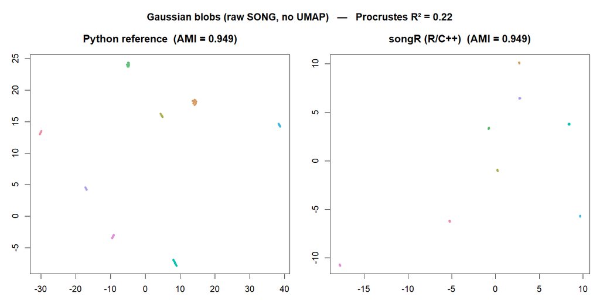

### MNIST (PCA→20) — default UMAP-dispersed mode

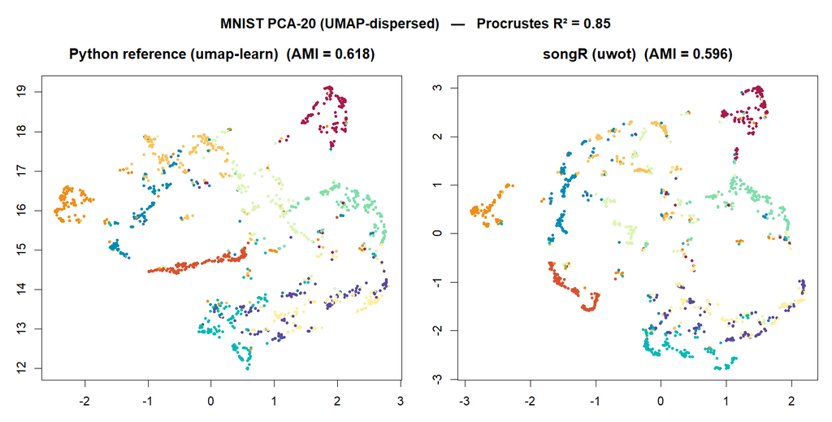

### Fashion-MNIST (PCA→20) — default UMAP-dispersed mode

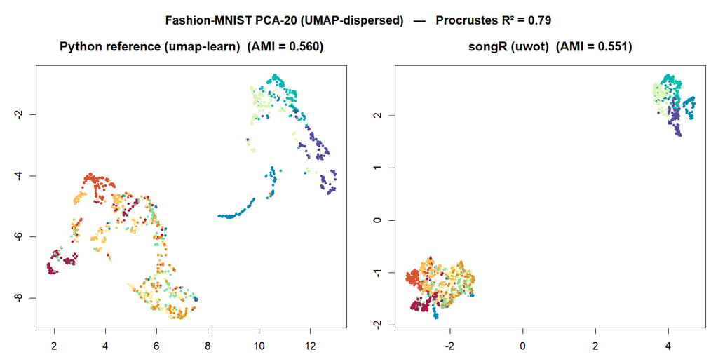

## Reproduce this report

```bash
Rscript tests/reproduction-report/generate_comparison.R      # figures + tables
quarto render tests/reproduction-report/comparison.qmd        # html + pdf
```

The reference fixtures are regenerated by `tests/testthat/fixtures/reference/gen_fixtures.py` (pinned env: `data-raw/reproduction/environment.yml`). The parity is enforced in CI by `tests/testthat/test-reference-parity.R`.

## Citation

Senanayake, D. A., Wang, W., Naik, S. H., & Halgamuge, S. (2021). Self-Organizing Nebulous Growths for Robust and Incremental Data Visualization. *IEEE TNNLS*, 32(10), 4588–4602. doi:10.1109/TNNLS.2020.3023941